# Sample and Quality

```
NA
```

It has not: - excluded respondents just because finished == 0, they passed only 2 or only 1 attention checks.

Relevant quality variables created in data prep are:

block attn_q9_pass attn_check_q17 attn_q114_pass attn_pass_count attn_fail_count duration_minutes speeder

And the pre-existing quality-check related variables were: progress duration_in_seconds finished respondent_id q9 q17 q114_4

## Q 1: response quality within sample

The first question I ask in this Rmd is what response quality looks like among respondents who are currently retained.

I’m thinking first of variables that help indicate respondent quality: 0. maybe progress 1. Their completion speed 2. How many attention checks they passed (we’ve excluded those who failed all 3) 3. Idiosyncratic responses. So far, I just know that within the experience variables of interest.

Then, we’ll turn to completion of my variables. Then, while I look at completion of variables, this doubles as looking at who my sample is.

### Progress and Finished

```
  17   18   23   24   28   30   31   32   34   37   38   41   42   48   49   73   86  100
   2   14    2    4    7    6    1    4    4    4    7    2    2    2    3    1    1 1987
```

Progress ranges from 17 to 100, mean is 97.8, everything else is 100. Finished is a 0-1 variable. 66 non-finishers.

[output not shown]

About 3% of the total sample.

### Speed

Completion speed. At first, we just want to know speeds/groups. We have already created: - duration_minutes (from duration_in_seconds) - speeder: people who finished in less than 12 minutes

Below brackets duration groups – it lives in data prep but I don’t think I saved the groups to the data file so recreating here

Basic facts of how long the current sample took to complete the survey:

```
NA
```

```
NA
```

```
NA
```

[output not shown]

| speeder | n |
| --- | --- |
| 0 | 1943 |
| 1 | 110 |

what have wea learned to this point?

[output not shown]

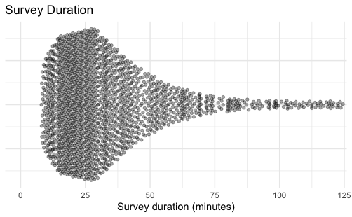

### Attention checks

We’ve already removed respondents who failed all three attention checks. Each respondents’ attention “count” – how many they passed– is saved in attn_pass_count.

Sept 2 2026: 1,600 respondents passed all three, 428 passed two, and 25 only passed 1, this reports.

These checks are: attn_q9_pass, attn_check_q17, attn_q114_pass

[output not shown]

| attn_pass_count | n |
| --- | --- |
| 1 | 25 |
| 2 | 428 |
| 3 | 1600 |

```
NA
```

```
NA
```

### Idiosyncratic responses.

Contact (Incarceration Victimization) Patterns

This is one variable where respondents could choose as many (3) as apply, where one of those 3 was no/unsure.

These two questions (q4_1 and q4_2) are actually coded as three questions each:

q4_1_1 (supposed to be 1 if self has been incarcerated, 0 otherrwise) q4_1_2 (supposed to be 1 if someone known has been incarcerated, 0 otherwise) q4_1_3 (supposed to be 1 if “no/don’t know”, 0 otherwise)

and

4_2_1 (supposed to be 1 if self has been incarcerated, 0 otherrwise) 4_2_2 (supposed to be 1 if someone known has been incarcerated, 0 otherwise) 4_2_3 (supposed to be 1 if “no/don’t know”, 0 otherwise)

Idiosyncratic responses then are when q4_1_3 == 1 and another q4_1 = 1, and/or when q4_2_3 == 1 and another q4_2 = 1.

```
data <- data %>%
  mutate(
    idiosync_inc = if_else(
      q4_1_3 == 1 & (q4_1_1 == 1 | q4_1_2 == 1),
      TRUE,
      FALSE,
      missing = NA
    ),

    idiosync_vict = if_else(
      q4_2_3 == 1 & (q4_2_1 == 1 | q4_2_2 == 1),
      TRUE,
      FALSE,
      missing = NA
    )
  )

data <- data %>%
  mutate(
    idiosync_impact = case_when(
      idiosync_inc == TRUE | idiosync_vict == TRUE ~ TRUE,
      idiosync_inc == FALSE & idiosync_vict == FALSE ~ FALSE,
      TRUE ~ NA
    )
  )
```

Idiosyncratic responses that appear

[output not shown]

| idiosync_inc | n |
| --- | --- |
| FALSE | 2044 |
| TRUE | 9 |

[output not shown]

| idiosync_vict | n |
| --- | --- |
| FALSE | 2042 |
| TRUE | 11 |

[output not shown]

| idiosync_impact | n |
| --- | --- |
| FALSE | 2033 |
| TRUE | 20 |

THE POINT: flagging these people as funny data so that I can describe my respondents and then also later decide if I need to drop more.

To inspect:

```
data <- data %>%
  mutate(
    contact_pattern_inc = paste0(
      if_else(is.na(q4_1_1), "NA", as.character(q4_1_1)),
      "_",
      if_else(is.na(q4_1_2), "NA", as.character(q4_1_2)),
      "_",
      if_else(is.na(q4_1_3), "NA", as.character(q4_1_3))
    ),

    contact_pattern_vict = paste0(
      if_else(is.na(q4_2_1), "NA", as.character(q4_2_1)),
      "_",
      if_else(is.na(q4_2_2), "NA", as.character(q4_2_2)),
      "_",
      if_else(is.na(q4_2_3), "NA", as.character(q4_2_3))
    )
  )
```

### Crosstabs

```
NA
```

```
NA
```

for data that has survived screening so far . . . -which analytically important questions were they eligible to see -which did they answer -what pattens of missingness exist -what consequences could those patterns have for analysis

q15_1 q15_2 q15_3 q15_4 q15_5 q15 q25_1 q25_2 q25_3 q25_4 q25_1 q4_1_1 q4_1_2 q4_1_3 q4_2_1 q4_2_2 q4_2_3, q62_1,q51_1 through q51_8, dem101, q32-38, q111,

Did these people answer variables I use? AAPOR explicitly distinguishes survey breakoff from item nonresponse. Someone can reach the end but skip questions; someone can break off before the end but still provide usable answers to the crucial variables. AAPOR recommends coding unanswered questions distinctly from substantive answers such as “don’t know” and “prefer not to answer,” and emphasizes documenting partial responses rather than automatically treating them as invalid cases.

And the breakoff literature gives another reason not to equate finished == 0 with poor-quality respondent. Breakoff can be related to questionnaire design, burden, where a question occurs, and respondent characteristics. Peytchev found that breakoffs did not simply look like inattentive respondents.

Need to look for: -loss of information/precision -selection

Selection: do people who don’t answer policy questions differ systematically in incarceratione xperience, ideology, education, survey engagement, race, underlying policy view?

Missing data lit says percent missing does not tell by itself whether missingness is dangerous/problematic. Ordinary regressions usually perform complete-case/listwise deletion for the variables appearing in that particular model. That means that adding a control variable with missing observations can change the regression sample. Coeficcient can then change partyly becuase added the control but also partialyl because the model is being estimated with a different sample.

### Crosstabs

Retained Respondents who did not finish

```
NA
```

```
NA
```

what block are they in?

[output not shown]

```
NA
```

| Experiences | nonfinishers | finishers |
| --- | --- | --- |
| Incarcerated | 8 | 162 |
| Know incarcerated | 21 | 668 |
| Victims | 60 | 267 |

- 8 incarcerated
- 21 know incarcerated
- 60 victims

[output not shown]

| attn_pass_count | speeder | n |
| --- | --- | --- |
| 1 | 0 | 21 |
| 1 | 1 | 4 |
| 2 | 0 | 351 |
| 2 | 1 | 77 |
| 3 | 0 | 1571 |
| 3 | 1 | 29 |

| NAs in | nonfinishers | finishers |
| --- | --- | --- |
| d_crim_abc |  |  |
| d_incppl_pris_abc |  |  |
| d_incwomen_abc |  |  |
| all Police Questions (5) | 16 |  |
| all prison questions | all 16 NAs | 170 (171 for 25_4 and 6) |
| q25_1 | 16 |  |
| q25_2 | … |  |
| re enfranchisement | 35 | 497 |
| jail voting | 35 | 497 |

deservingness scores aside, variables I use/care about (in names at THIS stage):

q15_1 q15_2 q15_3 q15_4 q15_5 q15 q25_1 q25_2 q25_3 q25_4 q25_1 q4_1_1 q4_1_2 q4_1_3 q4_2_1 q4_2_2 q4_2_3

```
NA
```